# Eurovision Song Contest country profile

2025-05-02

# Serbia

## Participation and successes

Serbia has participated in the Eurovision Song Contest 16 times. It made it to the final round 13 times - that’s 81.2%.

Serbia has won 1 times. Its most successful performance took place in the 2012 semi-final-2, when the country got 13.1% of all possible points.

## Final place distribution

Here’s how many times Serbia earned a particular place in the final round of Eurovision:

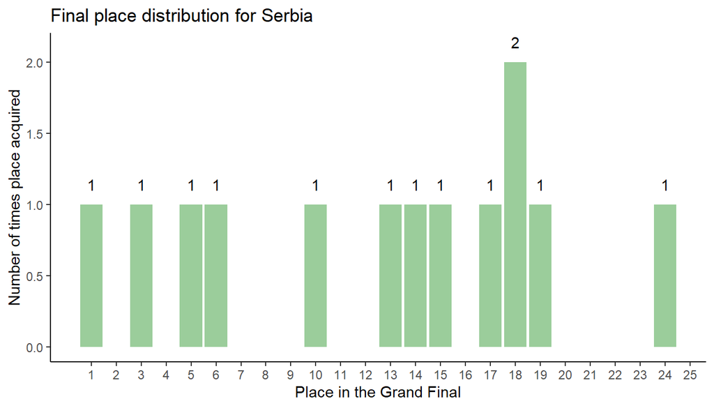

## Loyal besties

Below are the countries that have NEVER given Serbia zero points. The bar chart shows the lowest score those countries gave Serbia instead.

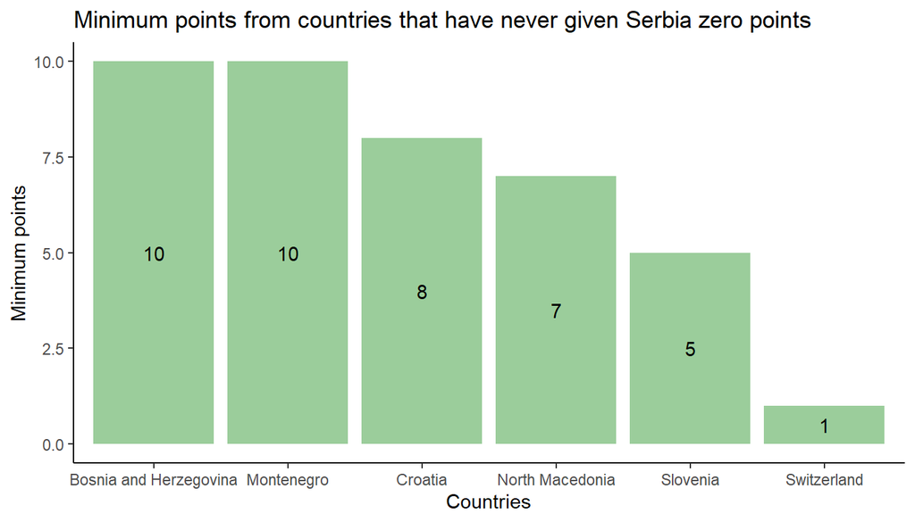

## Only zeros

On the other hand, here are the countries that have never given Serbia more than zero points.

```
## countries that have never given  Serbia  more than zero points:
##
## - Andorra
## - Turkey
```

## Birds of a feather sing together

The European Broadcasting Union started separating televote (votes cast by audience) and jury vote (votes cast by official representatives of each participating country) in 2016. Below is a chart that shows top five countries whose public voted for Serbia and top five countries that Serbia public voted for the most between 2016 and 2024:

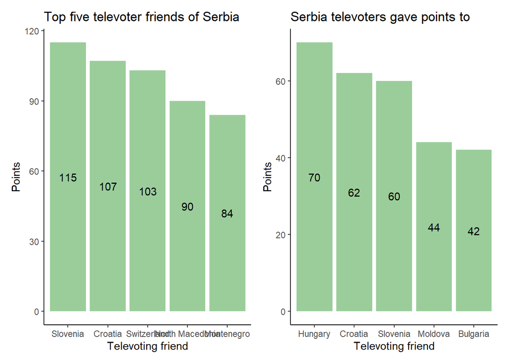

Below is a chart that shows top five countries whose jury voted for Serbia and top five countries that Serbia jury voted for the most between 2016 and 2024:

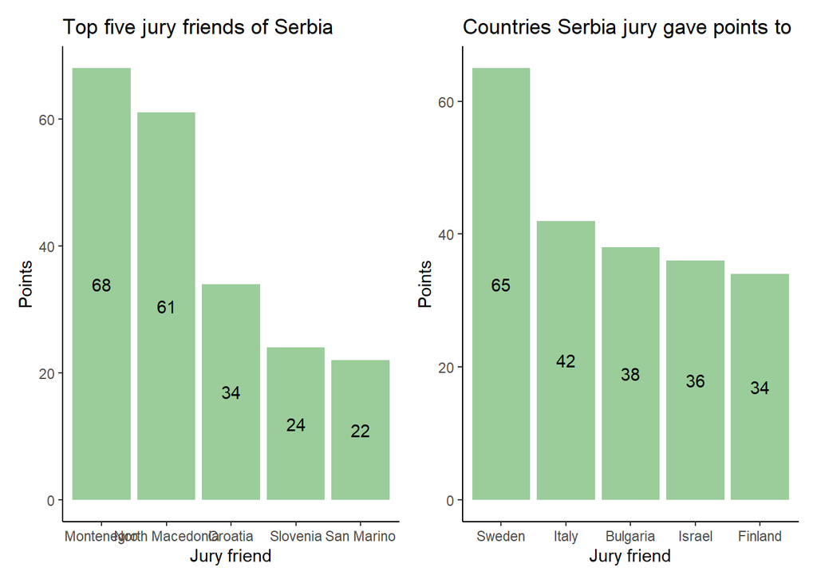

Finally, here is a chart that shows overall (televote and jury vote combined) top five countries that voted for Serbia and top five countries that Serbia voted for the most between 1957 and 2024:

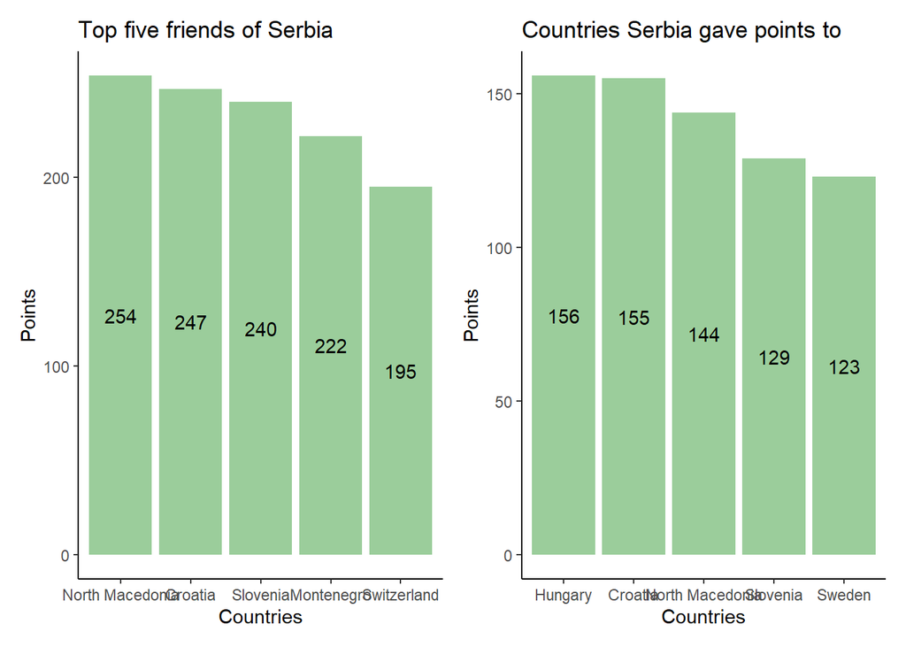